# MATH 106 - Applied Linear Statistical Models

mbanuelos22@csufresno.edu

## Introduction

Instructor: Prof. Mario Banuelos

Lecture: MWF 1:00 – 1:50 pm, Science I, Rm 242

Office Hours: MW 2:30 – 4:00 pm, Tu 4:30 – 5:30pm, and by appointment (PB 337)

Students: Introduction

## What are linear models?

A **linear model** is an equation that attempts to describe the **response** variable with a linear transformation of the **predictor** variable using the following form

**Example 1:** \[ Y \approx mX + b, \] where \(m\) is the slope and \(b\) is the intercept.

## Why study linear models?

Linear models help us understand the world around us:

- Are daughters taller than their mothers?
- Does changing class size affect success of students?
- Do countries with higher per person income have lower birth rates than countries with lower income?

Linear regression is the backbone of data science and many more advanced machine learning methods.

**This class:** Model real-world phenomena using linear regression and analyze the resulting models.

## Syllabus: Textbook

**Textbooks:** *Applied Linear Regression (ALR4)* , 4th Edition, S. Weisberg, 2014.

*An Introduction to Statistical Learning with Applications in R (ISLR)* , G. James, D. Witten, T. Hastie, and R. Tibshirani, 2013.

Both books are free and available online.

- On the course schedule, I list which chapters we will discuss. *You are responsible for reviewing these sections before lecture.*
- Homework is due one week after it is assigned.

## Syllabus: Quizzes, Midterms & Final Project

**Quizzes:** There will be a total of five quizzes. The **lowest quiz** will be dropped.

**Midterm Exams:** There will be two exams,

- Exam 1: Monday, March 9
- Exam 2: Friday, April 24
- No calculators, 3 \(\times\) 5 index cards allowed.

**Final Project Presentation:** Monday, May 11 from 1:15-3:15pm in Science I Rm 242 Final project is mandatory and more details will be provided in the future.

## Syllabus: Grade determination

Your grade will be based on the following

- Homework Assignments (20%, lowest score dropped)
- Class Participation (10%)
- Quizzes (10%, lowest score dropped)
- Midterms (20% each)
- Final Project (20%).

## Syllabus: Homework and Computing

- Homework will be assigned on a weekly basis.
- It is mandatory that you complete these assignments.
- Homework will be due **at 11:59pm** one week from assigned date.
- All homework **will be required to be typed and uploaded as a PDF or HTML** online through Canvas. **R** will also be required as a component of this course.
- You are encouraged to work in groups.
- Homework will be graded for completeness/effort as well as correctness. So do your best on every problem!

## Syllabus: Miscellaneous

- Bring 2 blue books next week to class.
- All portable electronic devices must be put away in class.
- You are responsible for all information discussed in class; if you skip class, make sure you get any important information from others.

## Course expectations

In this course, you are expected to

- Attend all lectures, and participate in this mathematical community (see course community agreement)
- **give space, take space**

## Other Expectations

You should also be **very familiar** with the following:

- Confidence intervals
- Hypothesis testing (t-tests vs z-tests)
- Graphical displays of data
- Exploratory data analysis

**HW1** will be assigned today after class. HW0 (already assigned) is an online survey which is a credit/no credit assignment.

## Motivating Example 1

- One of the first use of regression was during 1893 – 1898 by Karl Pearson (1857 – 1936) and Lee.
- Organized the collection of \(n = 1375\) heights of mothers in the United Kingdom under the age of 65 and one of their adult daughters over the age of 18.
- We are interested in predicting daughter height using mother height in `Heights` data.

## `Heights` data

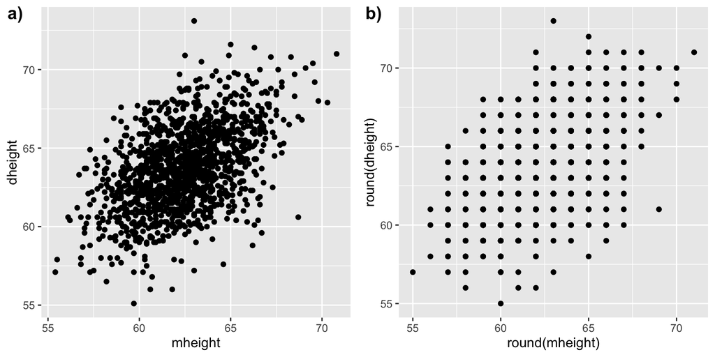

## Motivating Example 1 (continued)

In small groups, consider the following:

- What is wrong with the previous plot?
- What is the difference between plot a) and plot b)?
- Do taller mothers tend to have taller daughters?
- What is *jittering* and what does it do?

## Motivating Example 2

- In an 1857, Scottish physicist James D. Forbes (1809 –1868) discussed a series of experiments that he had done concerning the relationship between atmospheric pressure and the boiling point of water.
- The data for \(n = 17\) locales are reproduced in the data `Forbes`.

## `Forbes` data

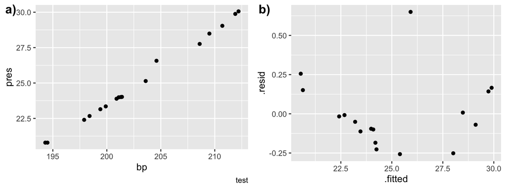

**Q:**

- How is the residual calculated?
- Are there any patterns you observe in the residuals?

## Scatterplots

Given a collection of one predictor \(X\) and one response \(Y\), scatterplots visually represent *potential* relationships between \(X\) and \(Y\).

- **Q:** If \(X\) and \(Y\) are uncorrelated, what would the resulting scatterplot look like?
- **Q:** How would you generate and plot such data?

## Mean Functions

Our interest centers on how the distribution of \(Y\) changes as \(X\) is varied, which is described by the **mean function** ,

\[ \text{E}(Y \;|\; X = x) = \text{ a function that depends on the value of }x \]

In the case of the mother and daughter height, we have

\[ \text{E}( \texttt{dheight}\; |\; \texttt{ mheight}=x)=\beta_0 + \beta_1 x \]

This particular mean function has 2 parameters, an intercept \(\beta_0\) and a slope \(\beta_1\). If we knew the values of the \(\beta\)s, then the mean function would be completely specified, but usually the \(\beta\)s need to be estimated from data.

## Variance Functions

Another part of the distribution of \(Y\) is described by the **variance function** ,

\[ \text{Var}(Y \;|\; X = x) \]

A frequent assumption in fitting linear regression models is that the variance function is the same for every value of x.

\[ \text{Var}(Y \;|\; X = x) = \sigma^2 \]

This is usually done for convenience but we will discuss general variance models in Ch. 7.